# Additional links:

- Link to [Rmd](https://github.com/madisonthantu/Behavioral-RP-recruiting-Fall-2023/blob/main/data_analysis_task.html) file
  - https://github.com/madisonthantu/Behavioral-RP-recruiting-Fall-2023/blob/main/data_analysis_task.html
- Link to html file
  - https://github.com/madisonthantu/Behavioral-RP-recruiting-Fall-2023/blob/main/data_analysis_task.html

# Data Analysis Task 1

**Clean the data. Consider what variables you might use to exclude observations.**

- Variables used for exclusion: If variable x != y, then exclude sample
  - Progress = 100%
  - Finished = True
  - consent = Agree
  - QID54_First Click, QID54_Last Click, QID54_Page Submit, QID54_Click Count != nan
  - passedattn = ‘yes’

```r
library(readxl)
# REF: https://stackoverflow.com/questions/2631780/set-the-plot-title-to-wrap-around-and-shrink-the-text-to-fit-the-plot
wrapper <- function(x, ...)
{
  paste(strwrap(x, ...), collapse = "\n")
}
# Read in data
# REF: https://stackoverflow.com/questions/47066336/trying-to-knit-but-cant-because-read-excel-function-is-not-being-recognized-in
data <- read_excel("Data - Fall 2023.xlsx", sheet = "Data")
df <- data.frame(data)
# unique(df[["UserLanguage"]])

# REF: https://chryswoods.com/beginning_r/dictionaries.html
col_val_constraints <- c("Progress"=100, "Finished"=TRUE, "consent"="AGREE", "passedattn"="yes")

# colnames(df)
# Removing samples based on exclusion criteria
df_cleaned <- subset(x = df,
    subset = Progress == 100 &
             Finished == TRUE &
             consent == "AGREE" &
             passedattn == "yes" &
             !is.na(QID54_First.Click) &
             !is.na(QID54_Last.Click) &
             !is.na(QID54_Page.Submit) &
             !is.na(QID54_Click.Count))

# unique(df[["UserLanguage"]])
summary(df_cleaned)
```

```
##    StartDate                         EndDate
##  Min.   :2021-01-27 12:12:35.00   Min.   :2021-01-27 12:16:04.00
##  1st Qu.:2021-01-27 12:12:42.00   1st Qu.:2021-01-27 12:17:22.75
##  Median :2021-01-27 12:12:46.00   Median :2021-01-27 12:18:14.00
##  Mean   :2021-01-27 12:12:54.20   Mean   :2021-01-27 12:18:28.82
##  3rd Qu.:2021-01-27 12:12:52.75   3rd Qu.:2021-01-27 12:19:23.00
##  Max.   :2021-01-27 12:15:09.00   Max.   :2021-01-27 12:22:03.00
##
##     Status           IPAddress            Progress   Duration..in.seconds.
##  Length:46          Length:46          Min.   :100   Min.   :187.0
##  Class :character   Class :character   1st Qu.:100   1st Qu.:271.5
##  Mode  :character   Mode  :character   Median :100   Median :318.5
##                                        Mean   :100   Mean   :334.0
##                                        3rd Qu.:100   3rd Qu.:395.0
##                                        Max.   :100   Max.   :505.0
##
##  Finished        RecordedDate                     ResponseId
##  Mode:logical   Min.   :2021-01-27 12:16:04.00   Length:46
##  TRUE:46        1st Qu.:2021-01-27 12:17:22.75   Class :character
##                 Median :2021-01-27 12:18:15.00   Mode  :character
##                 Mean   :2021-01-27 12:18:29.39
##                 3rd Qu.:2021-01-27 12:19:24.75
##                 Max.   :2021-01-27 12:22:04.00
##
##  RecipientLastName RecipientFirstName RecipientEmail ExternalReference
##  Mode:logical      Mode:logical       Mode:logical   Mode:logical
##  NA's:46           NA's:46            NA's:46        NA's:46
##
##
##
##
##
##  LocationLatitude LocationLongitude DistributionChannel UserLanguage
##  Min.   :23.75    Min.   :-121.95   Length:46           Length:46
##  1st Qu.:41.80    1st Qu.: -87.67   Class :character    Class :character
##  Median :41.89    Median : -87.62   Mode  :character    Mode  :character
##  Mean   :41.08    Mean   : -83.43
##  3rd Qu.:41.92    3rd Qu.: -87.60
##  Max.   :50.72    Max.   :  90.38
##
```

[output cut: 113 more lines]

```
##  Min.   :2.000
##  1st Qu.:2.000
##  Median :3.000
##  Mean   :2.565
##  3rd Qu.:3.000
##  Max.   :3.000
##
##  InitiatorType.binarychoice_DO_Q30
##  Min.   :1
##  1st Qu.:1
##  Median :1
##  Mean   :1
##  3rd Qu.:1
##  Max.   :1
##
```

```r
# For task 2, question (c)
df_c <- subset(df_cleaned, select = c(
    ResponseId,
    outcome_binary1
    ))
# Keeping only relevant columns
df_cleaned <- subset(df_cleaned, select = c(
    Progress,
    ResponseId,
    feelings_youalone,
    feelings_bothyoufirst,
    feelings_themalone,
    feelings_boththemfirst,
    feelings_neither,
    feelings_youaloneforgiven,
    initiator_type
    ))

# colnames(df_cleaned)
# df_cleaned
```

**Restructure the data as needed. (Hint: Within-subjects variables require making a “long” version of the dataset.)**

```r
library(reshape)

# Creating a long version of the cleaned dataset
# REF: https://www.digitalocean.com/community/tutorials/r-melt-and-cast-function
df_long <- melt(df_cleaned, id = c("ResponseId","initiator_type"))

dim(df_long)
```

```
## [1] 322   4
```

**Include significance testing.** **Include all code for reproducing your analyses and figures.**

### 1. Whether people care about getting a return apology after being the first to apologize;

- Conduct significance testing on variables of: ‘feelings_youalone’ v. ‘feelings_bothyoufirst’

```r
library(stats)
library(ggplot2)
library(jtools)

df_q1 <- subset(df_cleaned, select = c(
    ResponseId,
    feelings_youalone,
    feelings_bothyoufirst
    ))
# REF: https://www.r-bloggers.com/2021/10/paired-sample-t-test-using-r/
df_q1_long <- melt(df_q1, id="ResponseId")
# attach(df_q1_long)
# Summary statistics of `feelings_youalone` v. `feelings_bothyoufirst`
by(data = df_q1_long,
   INDICES = df_q1_long[["variable"]],
   FUN = summary)
```

```
## df_q1_long[["variable"]]: feelings_youalone
##   ResponseId                         variable      value
##  Length:46          feelings_youalone    :46   Min.   :-30.00
##  Class :character   feelings_bothyoufirst: 0   1st Qu.:-30.00
##  Mode  :character                              Median :-20.00
##                                                Mean   :-18.61
##                                                3rd Qu.:-10.00
##                                                Max.   : 10.00
## ------------------------------------------------------------
## df_q1_long[["variable"]]: feelings_bothyoufirst
##   ResponseId                         variable      value
##  Length:46          feelings_youalone    : 0   Min.   :-30.000
##  Class :character   feelings_bothyoufirst:46   1st Qu.:  1.000
##  Mode  :character                              Median : 10.000
##                                                Mean   :  7.848
##                                                3rd Qu.: 20.000
##                                                Max.   : 30.000
```

```r
lapply(df_q1[,c("feelings_bothyoufirst", "feelings_youalone")], sd)
```

```
## $feelings_bothyoufirst
## [1] 14.29058
##
## $feelings_youalone
## [1] 12.01569
```

```r
# Correlation test
feelings_youalone <- df_q1[["feelings_youalone"]]
feelings_bothyoufirst <- df_q1[["feelings_bothyoufirst"]]
cor.test(x = feelings_youalone, y = feelings_bothyoufirst,
         method = c("pearson"),
         conf.level = 0.95)
```

```
##
##  Pearson's product-moment correlation
##
## data:  feelings_youalone and feelings_bothyoufirst
## t = 3.3844, df = 44, p-value = 0.001509
## alternative hypothesis: true correlation is not equal to 0
## 95 percent confidence interval:
##  0.1891307 0.6579663
## sample estimates:
##       cor
## 0.4544761
```

```r
t.test(feelings_youalone,
    feelings_bothyoufirst,
    paired=TRUE)
```

```
##
##  Paired t-test
##
## data:  feelings_youalone and feelings_bothyoufirst
## t = -12.932, df = 45, p-value < 2.2e-16
## alternative hypothesis: true mean difference is not equal to 0
## 95 percent confidence interval:
##  -30.57694 -22.33611
## sample estimates:
## mean difference
##       -26.45652
```

```r
# REF: http://www.sthda.com/english/wiki/ggplot2-box-plot-quick-start-guide-r-software-and-data-visualization
png("q1_box_plot.png")
p <- ggplot(df_q1_long, aes(x=variable, y=value)) +
    geom_boxplot() +
    xlab("Scenario") + ylab("Sentiment score") +
    theme_apa(legend.font.size = 16,
      x.font.size = 16,
      y.font.size = 16,
      facet.title.size = 16)  +
    theme(aspect.ratio = 1/2,
      legend.title = element_text(size = 12),
      axis.text.y = element_text(size = 12),
      axis.text.x = element_text(size = 12),
      plot.title = element_text(hjust=0.5)) +
    scale_y_continuous(breaks=seq(-30,30,10)) +
    ggtitle(wrapper("Distribution of sentiment scores for receiving a return apology versus not", width = 70))
print(p)
dev.off()
```

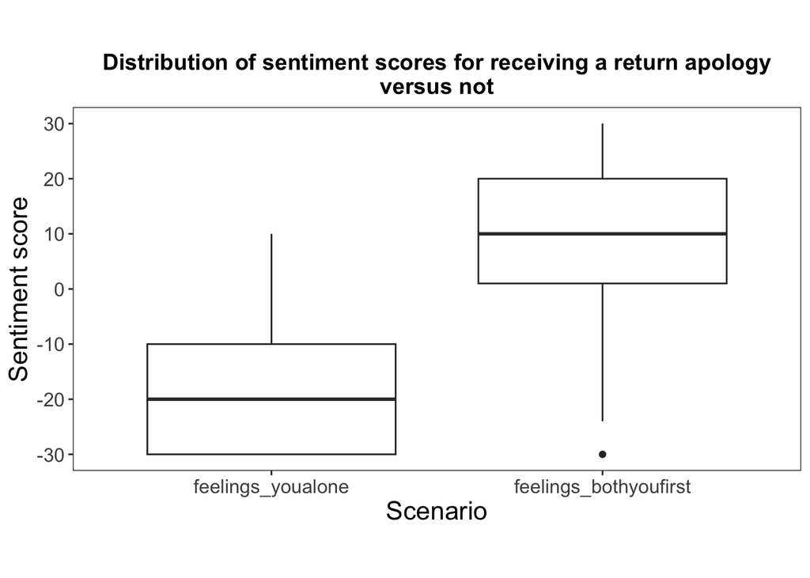

```r
p
```

```r
# Homogeneity in variances - above REF
bartlett.test(df_q1_long[["value"]] ~ df_q1_long[["variable"]])
```

```
##
##  Bartlett test of homogeneity of variances
##
## data:  df_q1_long[["value"]] by df_q1_long[["variable"]]
## Bartlett's K-squared = 1.3313, df = 1, p-value = 0.2486
```

```r
# Paired samples t-test - REF: https://www.statmethods.net/stats/ttest.html
q1.t_test <- t.test(
    formula=df_q1_long[["value"]] ~ df_q1_long[["variable"]],
    paired=TRUE)
q1.t_test
```

```
##
##  Paired t-test
##
## data:  df_q1_long[["value"]] by df_q1_long[["variable"]]
## t = -12.932, df = 45, p-value < 2.2e-16
## alternative hypothesis: true mean difference is not equal to 0
## 95 percent confidence interval:
##  -30.57694 -22.33611
## sample estimates:
## mean difference
##       -26.45652
```

```r
# detach(df_q1_long)
```

### 2. Whether this varies as function of individual differences in “initiator type”; and

- ‘initiator_type’ variable

```r
library(dplyr)
library(car)
# REF: https://www.scribbr.com/statistics/anova-in-r/
df_q2 <- subset(df_cleaned, select = c(
    ResponseId,
    feelings_youalone,
    feelings_bothyoufirst,
    initiator_type
    ))

df_q2_long <- melt(df_q2, id=c("ResponseId", "initiator_type") )
# attach(df_q2_long)

group_by(df_q2_long, initiator_type, variable) %>%
  summarise(
    mean = round(mean(value, na.rm = TRUE), 4),
    sd = round(sd(value, na.rm = TRUE), 4),
    count = length(value)
  )
```

```
## # A tibble: 6 × 5
## # Groups:   initiator_type [3]
##   initiator_type variable                mean    sd count
##   <chr>          <fct>                  <dbl> <dbl> <int>
## 1 always         feelings_youalone     -13.5  11.9     21
## 2 always         feelings_bothyoufirst  12.8  11.1     21
## 3 conditional    feelings_youalone     -24.5  11.3     15
## 4 conditional    feelings_bothyoufirst   5.07 16.4     15
## 5 never          feelings_youalone     -20.6   9.20    10
## 6 never          feelings_bothyoufirst   1.7  14.9     10
```

```r
aov1.results <- aov(value ~ variable + initiator_type + variable:initiator_type, data=df_q2_long)
print("Type I ANOVA, assuming no significant interaction")
```

```
## [1] "Type I ANOVA, assuming no significant interaction"
```

```r
summary(aov1.results)
```

```
##                         Df Sum Sq Mean Sq F value   Pr(>F)
## variable                 1  16099   16099 101.965 2.89e-16 ***
## initiator_type           2   1951     975   6.178  0.00311 **
## variable:initiator_type  2    158      79   0.500  0.60828
## Residuals               86  13578     158
## ---
## Signif. codes:  0 '***' 0.001 '**' 0.01 '*' 0.05 '.' 0.1 ' ' 1
```

```r
aov_mod <- lm(value ~ variable*initiator_type, data=df_q2_long)
# print("Type II ANOVA, assuming no significant interaction")
# Anova(aov_mod.results, type=2)
print("Type III ANOVA, assuming significant interaction")
```

```
## [1] "Type III ANOVA, assuming significant interaction"
```

```r
Anova(aov_mod, type=3)
```

```
## Anova Table (Type III tests)
##
## Response: value
##                          Sum Sq Df F value    Pr(>F)
## (Intercept)              3813.8  1 24.1551 4.208e-06 ***
## variable                 7228.6  1 45.7836 1.526e-09 ***
## initiator_type           1107.6  2  3.5075   0.03433 *
## variable:initiator_type   157.9  2  0.5000   0.60828
## Residuals               13578.2 86
## ---
## Signif. codes:  0 '***' 0.001 '**' 0.01 '*' 0.05 '.' 0.1 ' ' 1
```

```r
png("q2_box_plot.png")
p <- ggplot(df_q2_long, aes(x=variable, y=value, fill=initiator_type)) +
    geom_boxplot() +
    xlab("Scenario") + ylab("Sentiment score") +
    labs(fill='Initiator Type') +
    theme_apa(legend.font.size = 12,
      x.font.size = 16,
      y.font.size = 16,
      facet.title.size = 16,
      legend.use.title = TRUE) +
    theme(aspect.ratio = 1/2,
      legend.title = element_text(size = 12),
      axis.text.y = element_text(size = 12),
      axis.text.x = element_text(size = 12),
      plot.title = element_text(hjust=0.5)) +
    scale_y_continuous(breaks=seq(-30,30,10)) +
    ggtitle(wrapper("Distribution of sentiment scores for receiving a return apology versus not, according to initiator type", width = 70))
print(p)
dev.off()
```

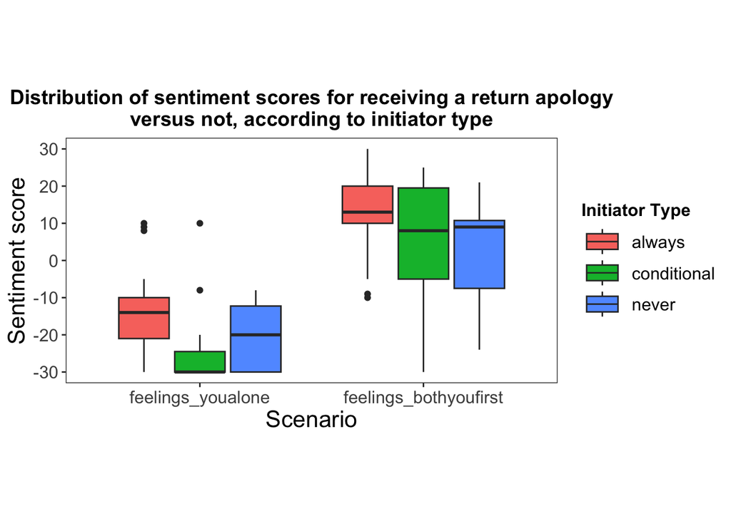

```r
p
```

```r
# detach(df_q2_long)
```

### 3. Whether a return apology is simply viewed as a form of forgiveness.

- Conduct significance testing on variables of: ‘feelings_bothyoufirst’ v. ‘feelings_youaloneforgiven’

```r
df_q3 <- subset(df_cleaned, select = c(
    ResponseId,
    feelings_youalone,
    feelings_youaloneforgiven,
    feelings_bothyoufirst
    ))
# Correlation test
cor.test(x = df_q3[["feelings_youaloneforgiven"]], y = df_q3[["feelings_bothyoufirst"]],
         method = c("pearson"),
         conf.level = 0.95)
```

```
##
##  Pearson's product-moment correlation
##
## data:  df_q3[["feelings_youaloneforgiven"]] and df_q3[["feelings_bothyoufirst"]]
## t = 2.3261, df = 44, p-value = 0.02468
## alternative hypothesis: true correlation is not equal to 0
## 95 percent confidence interval:
##  0.04493746 0.56676988
## sample estimates:
##       cor
## 0.3309186
```

```r
# REF: https://www.r-bloggers.com/2021/10/paired-sample-t-test-using-r/
df_q3_long <- melt(df_q3, id="ResponseId")
# attach(df_q3_long)
# Summary statistics of `feelings_youalone` v. `feelings_bothyoufirst`
group_by(df_q3_long, variable) %>%
  summarise(
    mean = round(mean(value, na.rm = TRUE), 6),
    sd = round(sd(value, na.rm = TRUE), 6),
    count = length(value)
  )
```

```
## # A tibble: 3 × 4
##   variable                    mean    sd count
##   <fct>                      <dbl> <dbl> <int>
## 1 feelings_youalone         -18.6   12.0    46
## 2 feelings_youaloneforgiven -14.3   15.6    46
## 3 feelings_bothyoufirst       7.85  14.3    46
```

```r
# Plotting - above REF
png("q3_box_plot.png")
p <- ggplot(df_q3_long, aes(x=variable, y=value)) +
    geom_boxplot() +
    xlab("Scenario") + ylab("Sentiment score") +
    theme_apa(legend.font.size = 16,
      x.font.size = 16,
      y.font.size = 16,
      facet.title.size = 16)  +
    theme(aspect.ratio = 1/2,
      legend.title = element_text(size = 12),
      axis.text.y = element_text(size = 12),
      axis.text.x = element_text(size = 12),
      plot.title = element_text(hjust=0.5)) +
    scale_y_continuous(breaks=seq(-30,30,10)) +
    ggtitle(wrapper("Distribution of sentiment scores for receiving a return apology versus no return apology versus receiving forgiveness", width = 70))
print(p)
dev.off()
```

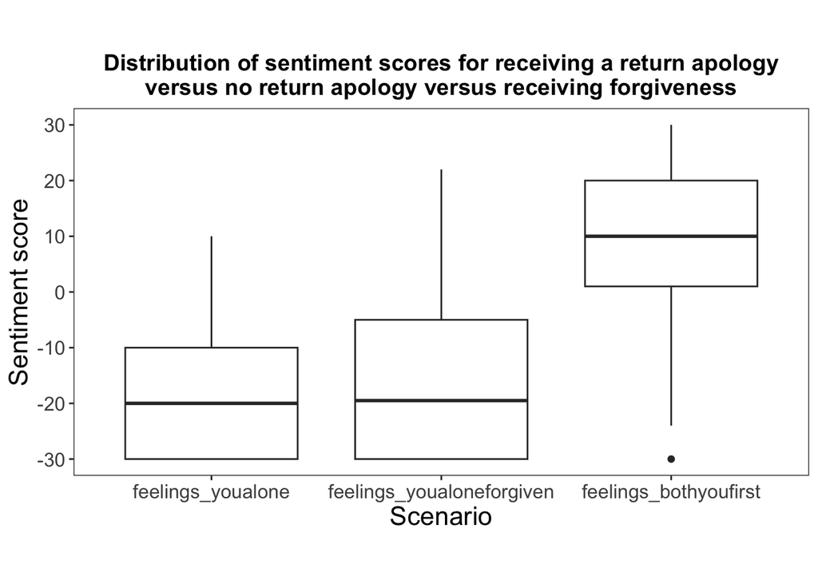

```r
p
```

```r
# Homogeneity in variances - above REF
bartlett.test(value ~ variable, data = df_q3_long)
```

```
##
##  Bartlett test of homogeneity of variances
##
## data:  value by variable
## Bartlett's K-squared = 3.0773, df = 2, p-value = 0.2147
```

```r
t.test(df_q3[,"feelings_youaloneforgiven"],
    df_q3[,"feelings_bothyoufirst"],
    paired=TRUE)
```

```
##
##  Paired t-test
##
## data:  df_q3[, "feelings_youaloneforgiven"] and df_q3[, "feelings_bothyoufirst"]
## t = -8.6488, df = 45, p-value = 3.996e-11
## alternative hypothesis: true mean difference is not equal to 0
## 95 percent confidence interval:
##  -27.25729 -16.96010
## sample estimates:
## mean difference
##        -22.1087
```

```r
pairwise.t.test(df_q3_long[["value"]], df_q3_long[["variable"]], p.adjust.method = "bonferroni", paired = TRUE)
```

```
##
##  Pairwise comparisons using paired t tests
##
## data:  df_q3_long[["value"]] and df_q3_long[["variable"]]
##
##                           feelings_youalone feelings_youaloneforgiven
## feelings_youaloneforgiven 0.11              -
## feelings_bothyoufirst     2.8e-16           1.2e-10
##
## P value adjustment method: bonferroni
```

```r
# detach(df_q3_long)
```

# Data Analysis Task 2

**Describe your observations in 1-2 sentences.**

In general, participants associated the highest positive sentiments with scenarios in which both them and the other person apologizes. Additionally, the scenarios in which no apoogy is received from the other person are associated with negative sentiments, even if the other person explicitly provides their forgiveness.

```r
df_a <- subset(df_cleaned, select = c(
    ResponseId,
    feelings_youalone,
    feelings_bothyoufirst,
    feelings_themalone,
    feelings_boththemfirst,
    feelings_neither,
    feelings_youaloneforgiven
    ))
df_a_long <- melt(df_a, value.name = "scenario", id = 'ResponseId')
colnames(df_a_long)[2] ="scenario"
# attach(df_a_long)

# REF: http://www.sthda.com/english/wiki/ggplot2-error-bars-quick-start-guide-r-software-and-data-visualization
data_summary <- function(data, varname, groupnames){
  require(plyr)
  summary_func <- function(x, col){
    c(mean = mean(x[[col]], na.rm=TRUE),
      sd = sd(x[[col]], na.rm=TRUE))
  }
  data_sum<-ddply(data, groupnames, .fun=summary_func,
                  varname)
 return(data_sum)
}
data_summ <- data_summary(df_a_long, varname="value",
                    groupnames=c("scenario"))
# REFs:
# - http://www.sthda.com/english/wiki/ggplot2-barplots-quick-start-guide-r-software-and-data-visualization
# - https://stackoverflow.com/questions/30183199/ggplot2-plot-mean-with-geom-bar
png("task2_qA_bar_plot.png")
p<-ggplot(data=data_summ) +
    geom_bar(
        aes(x=reorder(scenario, -mean), y=mean),
            position = "dodge", stat = "identity", width=0.9) +
    xlab("Scenario") + ylab("Mean sentiment score") +
    theme_apa(legend.font.size = 12,
      x.font.size = 16,
      y.font.size = 16,
      facet.title.size = 16,
      legend.use.title = TRUE) +
    theme(aspect.ratio = 1/2,
      legend.title = element_text(size = 12),
      axis.text.y = element_text(size = 12),
      axis.text.x = element_text(size = 12, angle = 90),
      plot.title = element_text(hjust=0.5)) +
    scale_y_continuous(breaks=seq(-30,30,5)) +
    ggtitle("Avg. `feelings` score by scenario")
    geom_errorbar(
        aes(x=scenario, ymin=mean-sd, ymax=mean+sd),
        width=0.4, colour="orange", alpha=0.9, size=1.3)
```

```
## mapping: x = ~scenario, ymin = ~mean - sd, ymax = ~mean + sd
## geom_errorbar: na.rm = FALSE, orientation = NA, width = 0.4
## stat_identity: na.rm = FALSE
## position_identity
```

```r
print(p)
dev.off()
```

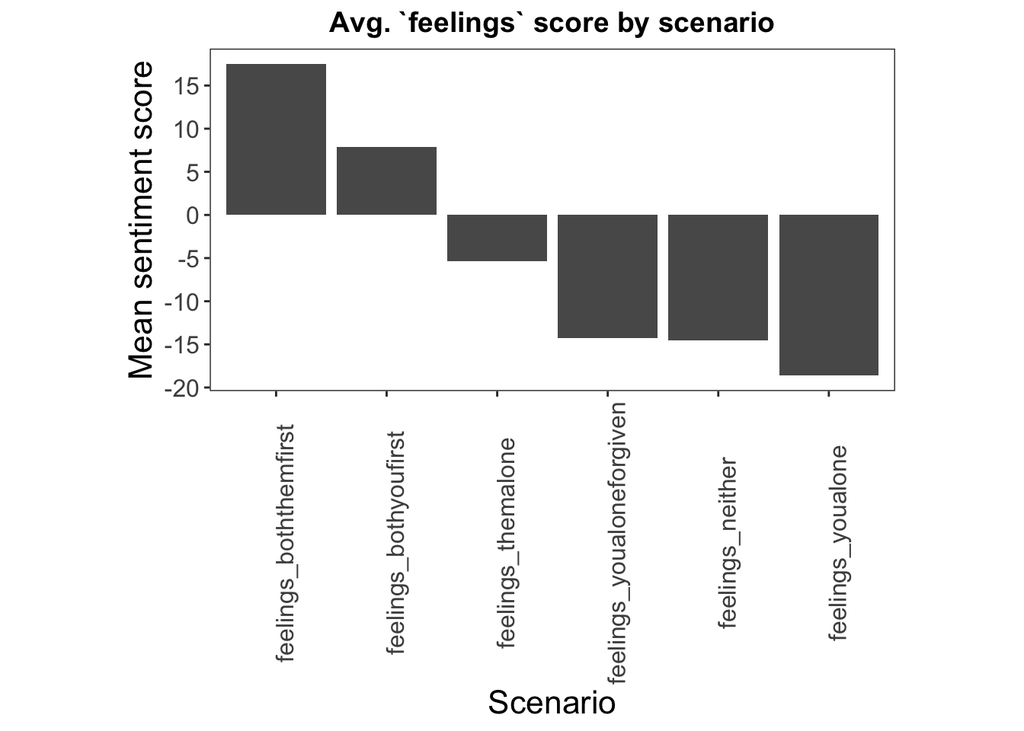

```r
p
```

```r
# detach(df_a_long)
```

### (b) Conduct a one way ANOVA to determine if there are differences in feelings across the six scenarios.

```r
# REF: http://www.sthda.com/english/wiki/one-way-anova-test-in-r
# Compute the analysis of variance
res.aov <- aov(value ~ scenario, data = df_a_long)
# Summary of the analysis
summary(res.aov)
```

```
##              Df Sum Sq Mean Sq F value Pr(>F)
## scenario      5  47408    9482   50.71 <2e-16 ***
## Residuals   270  50482     187
## ---
## Signif. codes:  0 '***' 0.001 '**' 0.01 '*' 0.05 '.' 0.1 ' ' 1
```

### Then perform pairwise t-tests to compare “feelings_youalone” to the other five scenarios.

```r
pairwise.t.test(df_a_long[["value"]], df_a_long[["scenario"]], p.adjust.method = "bonferroni", paired = TRUE)
```

```
##
##  Pairwise comparisons using paired t tests
##
## data:  df_a_long[["value"]] and df_a_long[["scenario"]]
##
##                           feelings_youalone feelings_bothyoufirst
## feelings_bothyoufirst     1.4e-15           -
## feelings_themalone        0.00135           0.00803
## feelings_boththemfirst    < 2e-16           0.00052
## feelings_neither          0.63127           1.1e-09
## feelings_youaloneforgiven 0.56652           6.0e-10
##                           feelings_themalone feelings_boththemfirst
## feelings_bothyoufirst     -                  -
## feelings_themalone        -                  -
## feelings_boththemfirst    1.9e-08            -
## feelings_neither          0.03896            9.1e-14
## feelings_youaloneforgiven 0.17833            8.2e-15
##                           feelings_neither
## feelings_bothyoufirst     -
## feelings_themalone        -
## feelings_boththemfirst    -
## feelings_neither          -
## feelings_youaloneforgiven 1.00000
##
## P value adjustment method: bonferroni
```

**Describe your observations in 1-2 sentences.**

The results of these pairwise t-test show that the differences of the `feelings_youalone` scenario with the scenarios of `feelings_bothyoufirst`, `feelings_themalone`, `feelings_boththemfirst` are statistically significant, which supports the observations made above that scenarios in which the other person apologizes are significantly different from the case in which the other person does not apologize.

### (c) Create a graph showing the proportion of people choosing each of the different options for the following variable: outcome_binary1.

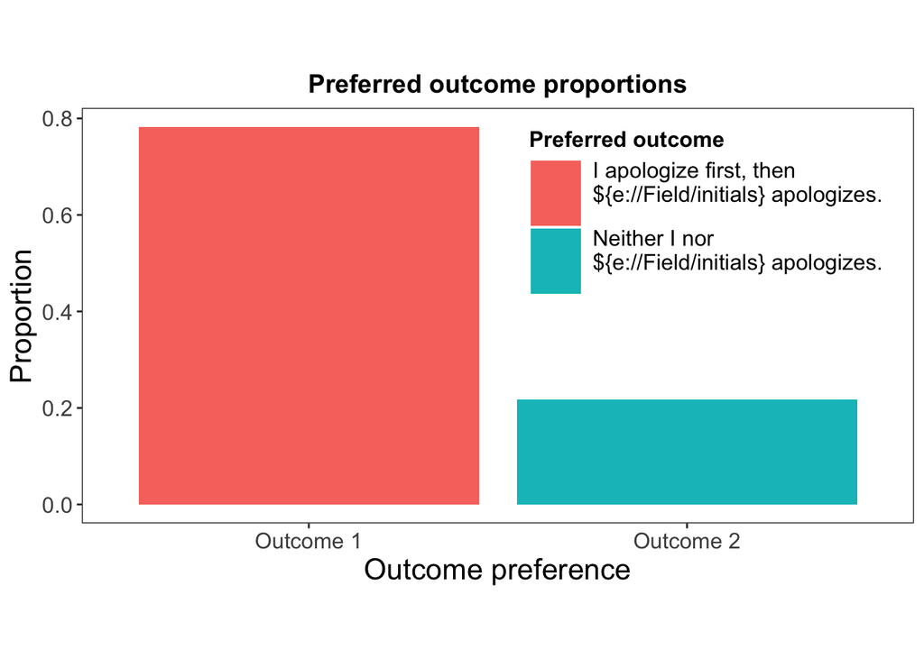

```r
bin_opts <- c("I apologize first, then \n${e://Field/initials} apologizes.\n", "Neither I nor \n${e://Field/initials} apologizes.\n")
t <- as.data.frame(table(df_c[["outcome_binary1"]], dnn = list("preferred_outcome")), responseName = "freq")
t$total <- sum(t$freq)
t$bin_label <- c("Outcome 1", "Outcome 2")

plot <- ggplot(data=t, aes(x=bin_label, y=freq/total, fill=preferred_outcome)) +
    geom_bar(stat="identity") +
    ggtitle("Preferred outcome proportions") +
    xlab("Outcome preference") + ylab("Proportion") +
    scale_fill_discrete(name = "Preferred outcome", labels = bin_opts) +
    theme_apa(legend.font.size = 12,
      x.font.size = 16,
      y.font.size = 16,
      facet.title.size = 16,
      legend.use.title = TRUE) +
    theme(aspect.ratio = 1/2,
      legend.title = element_text(size = 12),
      axis.text.y = element_text(size = 12),
      axis.text.x = element_text(size = 12),
      plot.title = element_text(hjust=0.5),
      legend.position = c(0.75, 0.75))

plot
```

### Conduct a test to determine if the proportion differences across the answers are significantly different from one another.

```r
# REF: https://www.rdocumentation.org/packages/stats/versions/3.6.2/topics/prop.test
prop.test(x = t$freq, n = t$total)
```

```
##
##  2-sample test for equality of proportions with continuity correction
##
## data:  t$freq out of t$total
## X-squared = 27.174, df = 1, p-value = 1.86e-07
## alternative hypothesis: two.sided
## 95 percent confidence interval:
##  0.3749093 0.7555255
## sample estimates:
##    prop 1    prop 2
## 0.7826087 0.2173913
```